# MATH1062 Lab3 Worksheet

Introduction to R

© University of Sydney MATH1062

28 August 2024

# Aim of Lab3

**Learning Outcome**

LO1. apply mathematical logic and statistical thinking to solve problems

LO3. identify appropriate methods to describe, summarise and visualise a given data set

LO5. apply statistical software such as R to analyse example sets of data

By now, you should already be able to:

- Import a given data-set into R
- Visualise variables by choosing an appropriate graphical summary

At the end of this Lab, you should be able to:

- Present and interpret graphical/numerical summaries of variables and understand their limitations
- Write a function in R
- Model a variable by a Normal curve, and explain how to find areas under the curve and percentiles.
- Use R to calculate areas under the Normal curve and percentiles.

# 1 Import data and IDA

- Save the data-file `math1005_cleaned.csv` in your data folder within your MATH1062 folder.
- **Import** the data into a variable called `math1005`:

```r
math1005 = read.csv("math1005_cleaned.csv")
```

This data was collected from an **optional survey** for MATH1005 students at the start of 2022 Semester 2. There are a total of **928 students** enrolled in this course.

- How many survey **responses** are there? How many **variables** are there?

```r
### write code here
dim(math1005)
```

```
## [1] 281   8
```

- What are the **columns** of your data and what are their **type**? Are they classified correctly?
  - *Hint: Use the function `str`. Other useful functions are `names` and`head`*.

```r
### write code here
str(math1005)
```

```
## 'data.frame':    281 obs. of  8 variables:
##  $ Gender       : chr  "Female" "Female" "Female" "Male" ...
##  $ International: chr  "Domestic" "Domestic" "International" "Domestic" ...
##  $ Major        : chr  "Physics, Chemistry" "Biomedical Engineering" "Statistics" "Transport" ...
##  $ Height       : num  154 182 156 172 193 167 NA 183 150 181 ...
##  $ ShoeSize     : num  9.5 9 9 8 13 40.5 NA 11 7 44 ...
##  $ Age          : int  18 22 18 29 18 19 19 18 18 20 ...
##  $ Country      : chr  "Australia" "Australia" "India" "Nepal" ...
##  $ Language     : chr  "English " "English" "Hindi" "Nepali" ...
```

```r
math1005$Country
```

```
##   [1] "Australia"
##   [2] "Australia"
##   [3] "India"
##   [4] "Nepal"
##   [5] "Australia "
##   [6] "Australia"
##   [7] "Scotland"
##   [8] "Australia"
##   [9] "Australia"
##  [10] "China"
##  [11] "New Zealand"
##  [12] "India"
##  [13] "Australia"
##  [14] "Australia"
##  [15] "Australia"
```

[output cut: 266 more lines]

# 2 Quantitative Data

## 2.1 Height

- Create a **graphical summary** for the **height** distribution of the cohort. Comment on the distribution, are there any **outliers**? Are there any issues with the data?

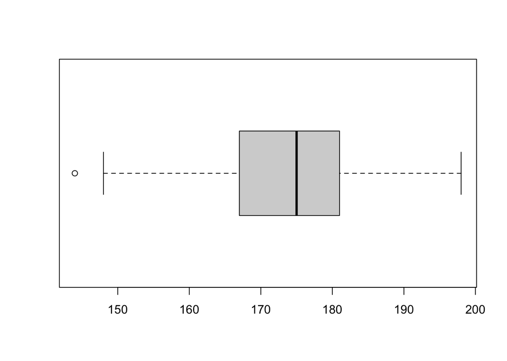

```r
### write code here

boxplot(math1005$Height,horizontal = TRUE)
```

**Answer**: The height distribution seems roughly symmetric with one outlier!

- Calculate some **numerical summaries** for the **heights**. Briefly summarise your findings. Here you may need to remove `NA`s in the variable before proceed.

```r
### write code here
height_cleaned = math1005$Height[!is.na(math1005$Height)]
summary(height_cleaned)
```

```
##    Min. 1st Qu.  Median    Mean 3rd Qu.    Max.
##   144.0   167.0   175.0   173.4   181.0   198.0
```

## 2.2 Write a function in R to compute the population standard deviation

In the lectures, we learned how to write a function in R. Here is your turn, we want to write a function to compute the **population standard deviation** of a data set. Let’s name the function `sdpop`.

- Complete the function in the following.

```r
# complete the following function
sdpop <- function(X){
  ### write your code here
  sdpop = sqrt(sum((X-mean(X))^2)/length(X))
  return(sdpop)

}
```

- Calculate the population SD of height and check if it is correct.

```r
### Apply your function sdpop here to height and check its correctness
sdpop(height_cleaned)
```

```
## [1] 9.706745
```

```r
sd(height_cleaned) * sqrt((length(height_cleaned)-1)/length(height_cleaned))
```

```
## [1] 9.706745
```

## 2.3 Age

- Create a **graphical summary** for the **age** distribution of the cohort. Comment on the distribution, are there any **outliers**? Are there any issues with the data?

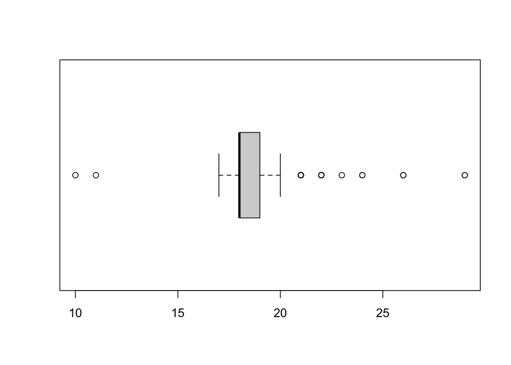

```r
### write code here
boxplot(math1005$Age,horizontal = TRUE)
```

- Calculate some **numerical summaries** for the **ages**. Briefly summarise your findings.

```r
### write code here
summary(math1005$Age)
```

```
##    Min. 1st Qu.  Median    Mean 3rd Qu.    Max.
##   10.00   18.00   18.00   18.84   19.00   29.00
```

## 2.4 Shoe Size

- Create a **graphical summary** for the **shoe size** distribution of the cohort. Comment on the distribution, are there any **outliers**? Are there any issues with the data? **Hint:** Some might response using a different shoe size convention, perhaps using EU instead of US.

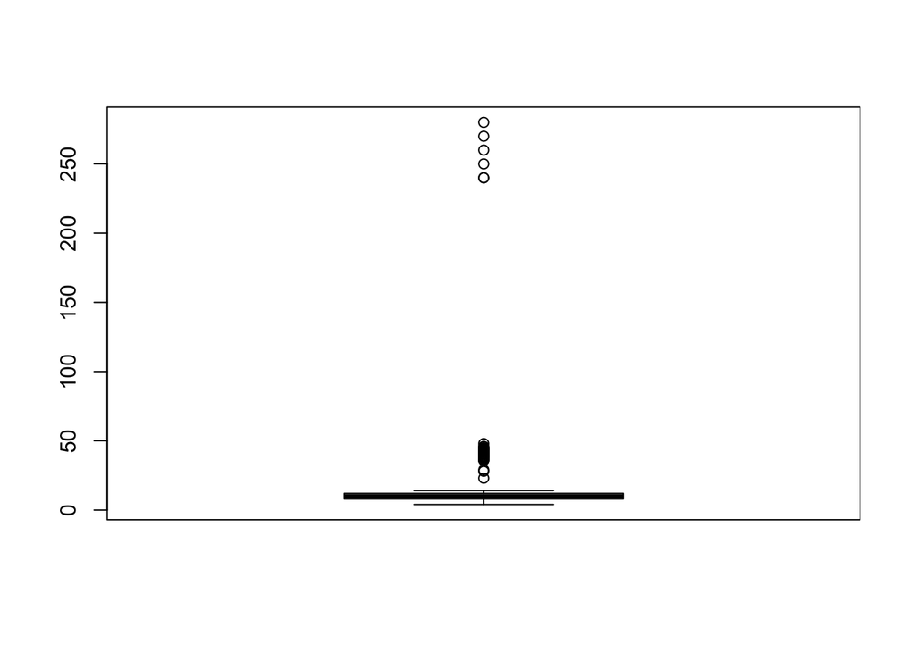

```r
### write code here
boxplot(math1005$ShoeSize)
```

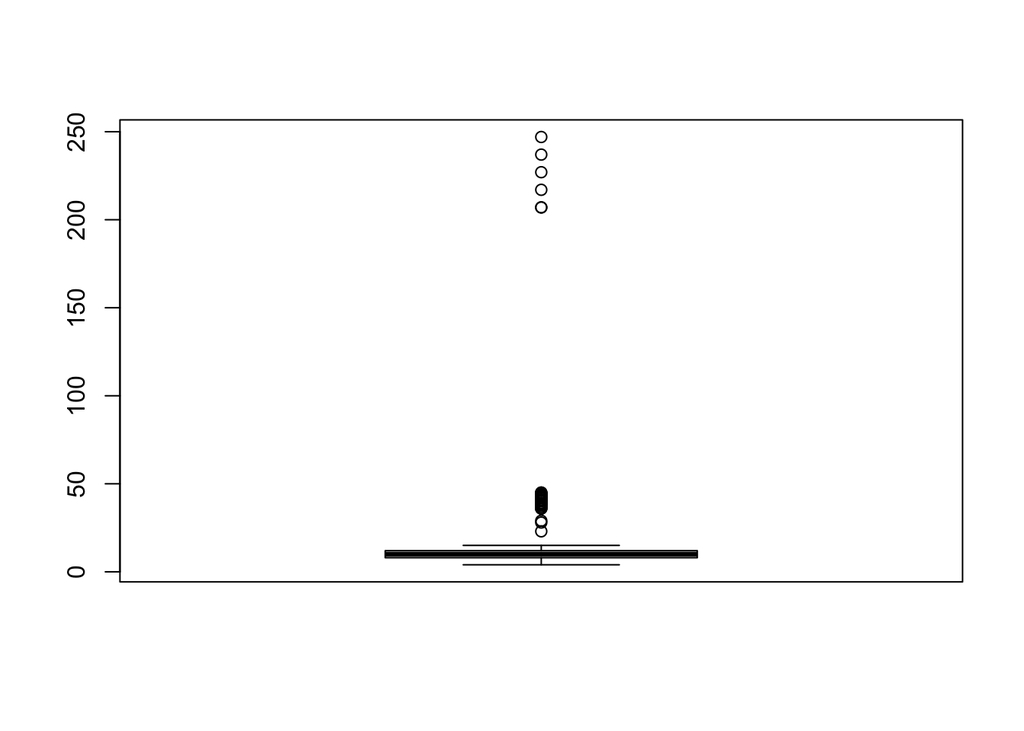

```r
convert_to_us <- function(size) {
  # Use ifelse to handle vectors
  us_size <- ifelse(size > 45, size - 33, size)
  return(us_size)
}


boxplot(convert_to_us(math1005$ShoeSize))
```

- Perform any appropriate **data cleaning**. You may also need to remove `NA`s here.

```r
### write code here
shoesize_cleaned = math1005$ShoeSize[!is.na(math1005$ShoeSize)]
shoesize_cleaned
```

```
##   [1]   9.5   9.0   9.0   8.0  13.0  40.5  11.0   7.0  44.0  10.5  10.0  12.0
##  [13]   8.0  29.0  42.0  45.0   7.5   7.0   9.5   9.0   8.0  11.0  48.0   4.0
##  [25]   8.0   9.0   9.5  11.0  10.0  11.0   9.0   9.0  11.5   9.0   9.0  37.0
##  [37]   6.0   8.0  38.0   8.0   9.0  10.0  10.0   7.5   8.0  12.0  12.0  44.5
##  [49]   6.0   8.0   7.0   7.0  11.0  10.0  43.0   7.0  10.0  42.5   6.0  12.0
##  [61]   7.0  36.0  39.0  10.0  44.0  11.0  11.0  11.0  11.0  12.0 260.0  43.0
##  [73]   9.0  10.0  39.0   9.0  12.0  23.0  11.0   7.0  10.0   5.0   4.5   7.0
##  [85]  43.0  43.0   8.0   9.0  11.0  42.0  14.0   7.0   5.0  10.0   8.0  13.0
##  [97]  11.0   9.0  11.0   7.0   7.0   8.5  39.0  11.5  12.0   9.0   8.0  11.0
## [109]  11.0  13.0   7.5   7.0  42.0  10.5   7.0  42.5   9.0   8.0  11.0   8.5
## [121]  10.5  41.0  36.0   9.0   9.0   8.0   8.0   9.0  11.0  11.0   8.0  10.0
## [133]   6.0  11.0  13.0   8.0   7.0  10.5  11.0  41.0   7.0  10.0  11.0   7.0
## [145]  12.0   9.0  12.0  13.0  12.5  12.0  12.0   7.0  39.0   7.0   9.0  42.5
## [157]   8.0   7.0   7.0  11.5   6.0  11.0   9.0  10.5  13.0  12.0  42.5   7.5
## [169]  43.0  44.5   7.0  11.5 280.0 250.0   8.0  39.0   8.0  10.0   8.5   6.0
## [181]   7.0  11.0  11.5   8.5  40.5   8.0  10.0  40.5   7.5   6.0   7.0  14.0
## [193]  43.0  11.0  42.5   9.0   7.0   7.5  10.0  10.0  45.0   9.5   9.0  10.0
## [205]   6.0  43.0   8.0  10.0  10.0  10.0  43.0   9.0  46.0   7.0  42.0   9.0
## [217]  37.0   7.0  42.5   6.0  12.0   9.0   7.0  11.0   8.0   6.5  10.0   9.0
## [229]  10.0   9.0   6.0  38.0 240.0   7.0   9.5   7.5   8.0   9.0  10.5   8.0
## [241]  11.0  11.0  43.0   8.0  38.0 240.0  43.0  10.5  44.0  10.0  11.0  40.0
## [253]  42.0  10.0  12.0  10.0   9.0   7.0  10.0   7.0  11.0  10.0  11.0   8.0
## [265]   9.0  10.0  36.0  11.0  28.0   9.5 270.0
```

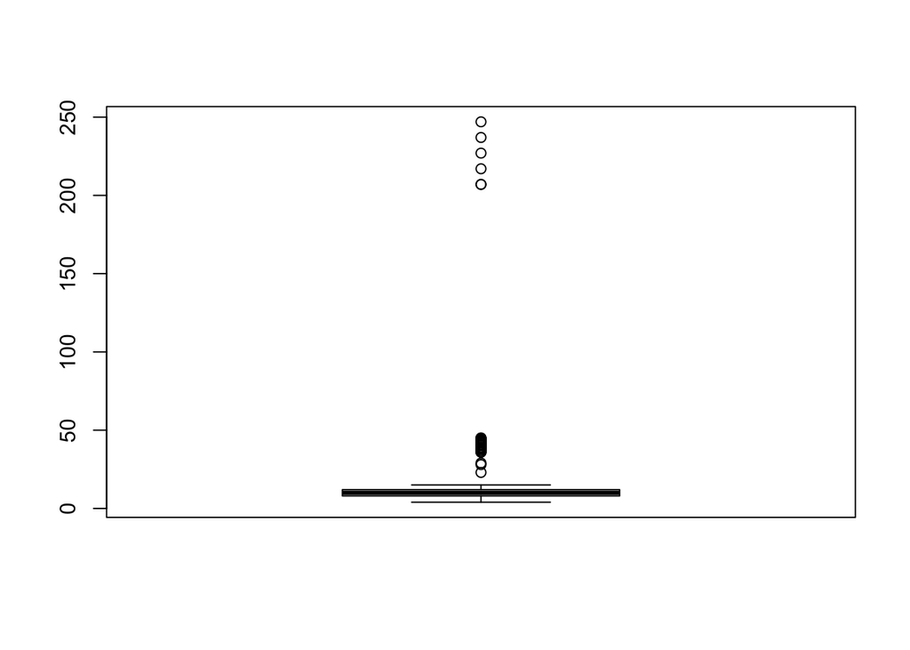

```r
boxplot(convert_to_us(shoesize_cleaned))
```

- Calculate some **numerical summaries** for the **shoe sizes**. Briefly summarise your findings.

```r
### write code here
summary(shoesize_cleaned)
```

```
##    Min. 1st Qu.  Median    Mean 3rd Qu.    Max.
##    4.00    8.00   10.00   20.73   12.00  280.00
```

Since Mean is much higher thatn median, the distribution might be right-skewed

# 3 Normal curve

We treat the collected heights as a sample of heights of students in U Syd. We want to fit a normal curve to the histogram of this height sample using the sample mean and sample SD (see Task 2.1).

## 3.1 Plot normal curve

The code `curve(dnorm(x, m, s), xlim = c(a, b), add=TRUE)` plots a normal curve with mean m and SD s in the domain $(a,b)$ on the x axis. The option `add=TRUE` let you add a normal curve to an existing plot. See the following for an example.

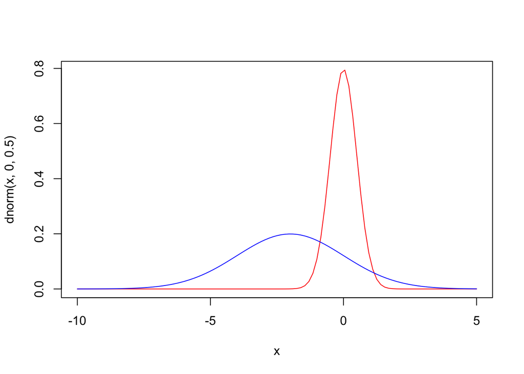

```r
### here is an example
curve(dnorm(x, 0, 0.5), xlim = c(-10, 5), col = "red")
curve(dnorm(x, -2, 2), xlim = c(-10, 5), col = "blue", add=TRUE)
```

- Now, plot the histogram of height and then plot the normal curve (defined by the sample mean and sample SD) on top of it. Is the normal curve a reasonable approximation to the histogram in this example?

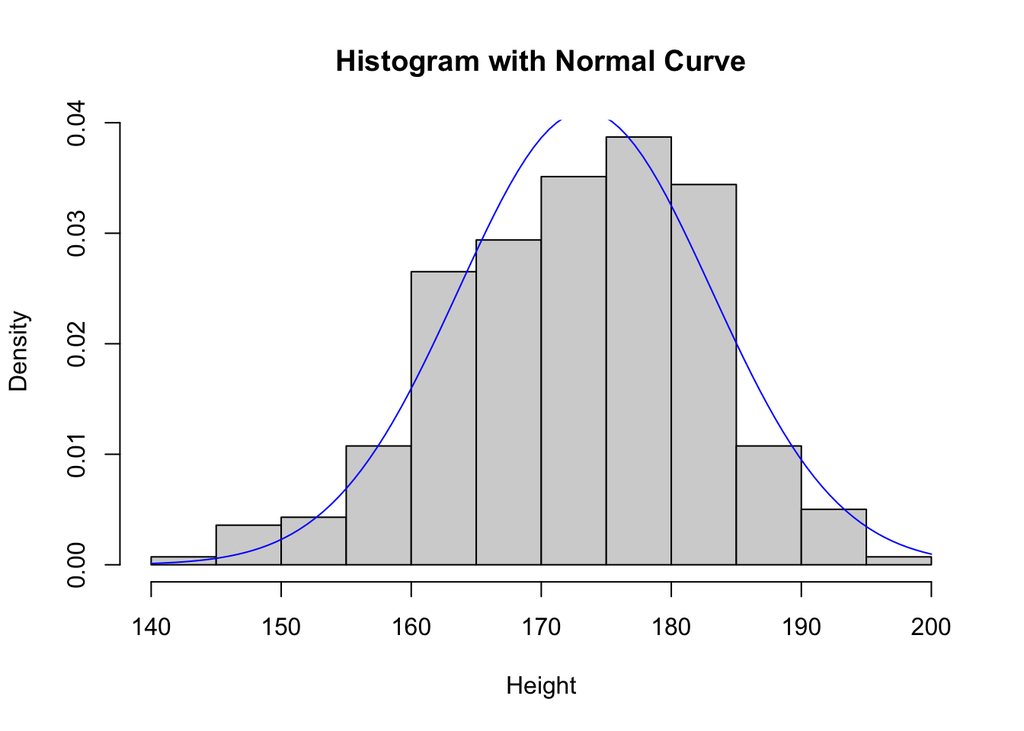

```r
### Write your code here

hist(height_cleaned, probability = TRUE, main = "Histogram with Normal Curve", xlab = "Height")
curve(dnorm(x, mean = mean(height_cleaned), sd = sd(height_cleaned)),
      col = "blue",
      xlim = c(140,200),
      add = TRUE)
```

## 3.2 Proportion and quantiles under normal curve

- Under the normal curve, are there more students under 160 cm than students taller than 190 cm? Write R code in the following to calculate this.

```r
### Write your code here
#
pnorm(160,mean(height_cleaned),sd(height_cleaned))
```

```
## [1] 0.08464811
```

```r
1-pnorm(190,mean(height_cleaned),sd(height_cleaned))
```

```
## [1] 0.04357546
```

- Under the normal curve, what is the 23% percentile of the student heights? Write R code in the following to calculate this.

```r
### Write your code here
#
qnorm(0.23,mean(height_cleaned),sd(height_cleaned))
```

```
## [1] 166.1809
```

# 4 Qualitative Data

## 4.1 International

- Create a **graphical summary** for the distribution of **domestic and international students** in the cohort.
  - *Hint: what type of graphical summary would be the most appropriate? You can refer to code in previous lectures and labs*.

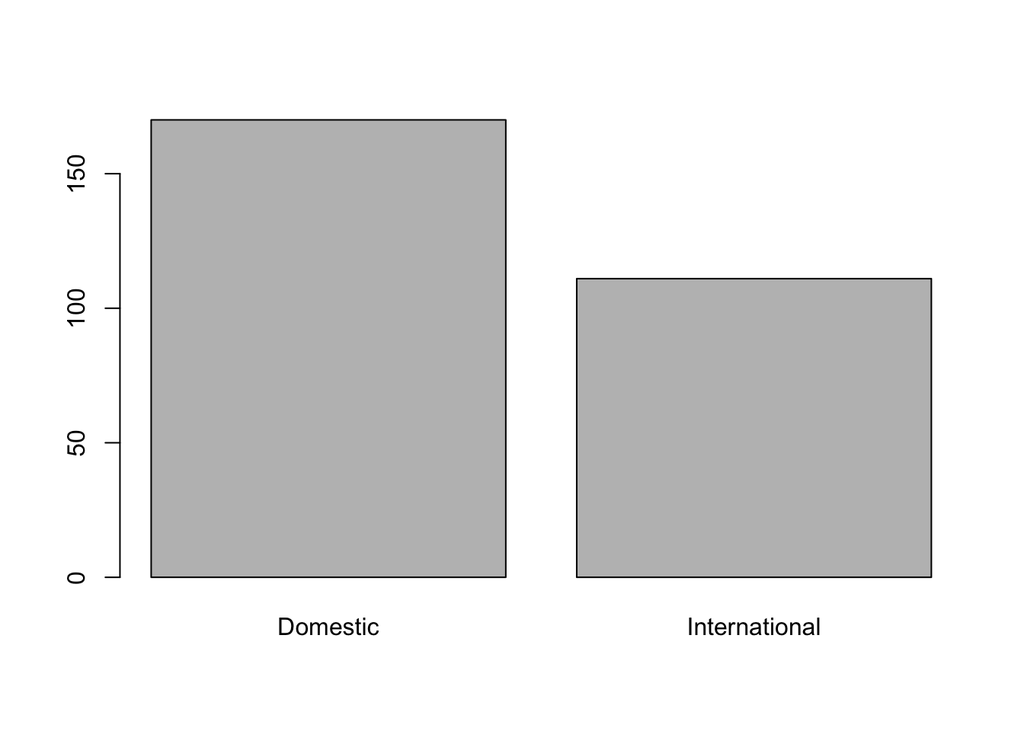

```r
### write code here

barplot(table(math1005$International))
```

- What is the **proportion** of **international students**? Briefly summarise your findings.
  - *Hint: `math1005$International == "International"` creates a list of `TRUE` and `FALSE` of whether each student is international or not. R can interpret `TRUE` as 1 and `FALSE` as 0.*

```r
### write code here

sum(math1005$International == "International")/length(math1005$International)
```

```
## [1] 0.3950178
```

## 4.2 Gender

- Create a **graphical summary** for the **gender** distribution of the cohort.

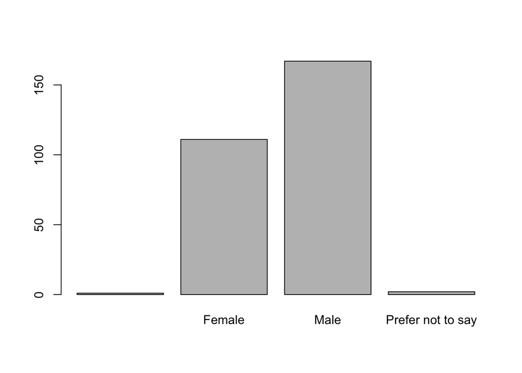

```r
### write code here
barplot(table(math1005$Gender))
```

- What is the **proportion** of **females**? Briefly summarise your findings

```r
### write code here

sum(math1005$Gender=="Female")/length(math1005$Gender)
```

```
## [1] 0.3950178
```

## 4.3 Country

This task contains some additional visualisation techniques not covered in lectures. These are not mandatory for learning other topics of this unit but can be useful in real life.

- Create a **barplot** for the **Country** that the students in the cohort were born in. Is it meaningful? Are there any issues with the data? How could this be improved?

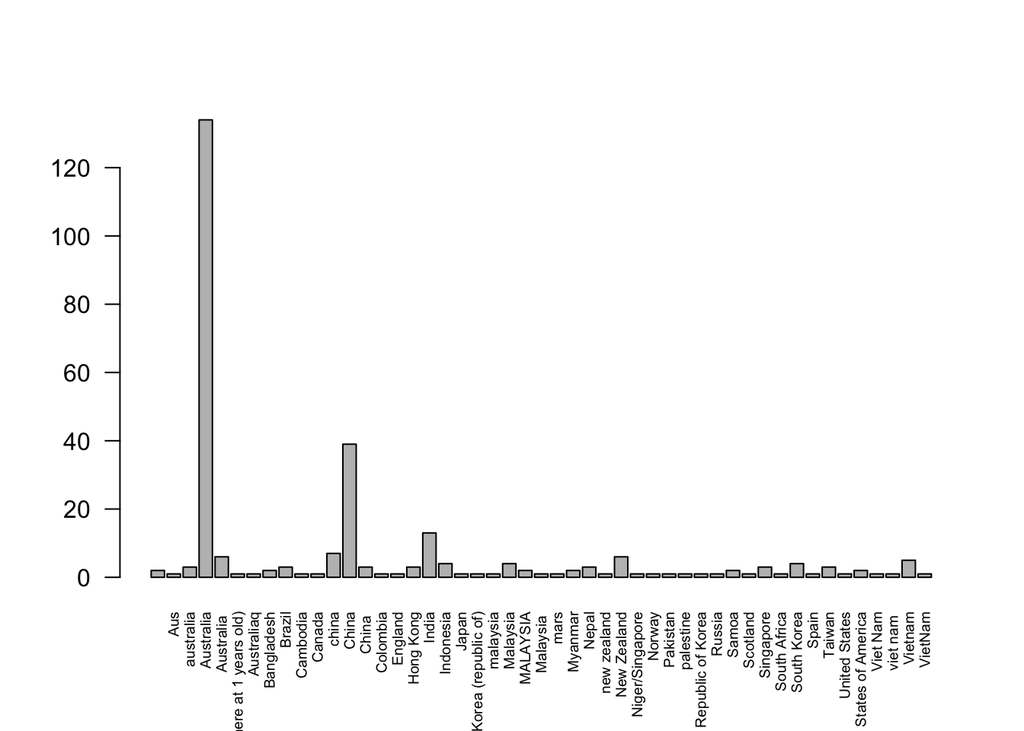

```r
### write code here
barplot(table(math1005$Country),las=2,cex.names = 0.6)
```

- Make a barplot of the **top 10 countries** among the cohort. Briefly summarise your findings.
  - *Hint: the `sort` function might be useful!*

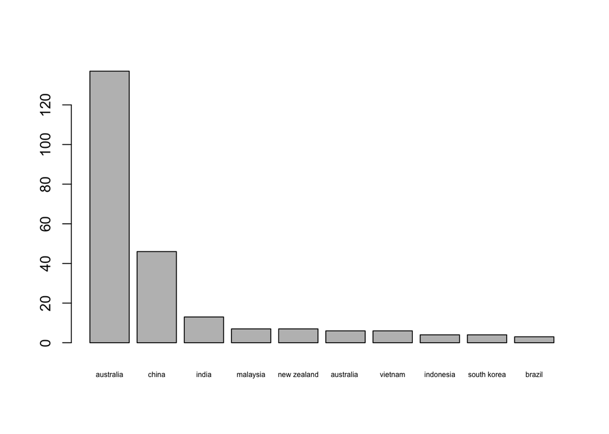

```r
### write code here

math1005$Country = tolower(math1005$Country)

country_counts = table(math1005$Country)
sorted_country_counts = sort(country_counts,decreasing = TRUE)

top_10_countries = head(sorted_country_counts, 10)

barplot(top_10_countries,cex.names=0.5)
```

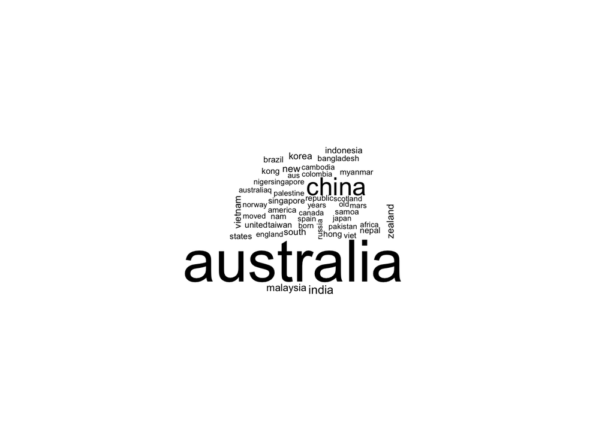

```r
library(wordcloud)
wordcloud(math1005$Country, min.freq = 1)
```